# Predicting Health Outcome (Classification Model)

Olamide Adu

2023-03-25

# Retrospective Health-data Analysis

Retrospective exploratory data analysis of intensive care unit health-data downloaded from kaggle.com already preprocessed by user @saurabhshahane.

**NB**: The [data](https://www.kaggle.com/datasets/saurabhshahane/in-hospital-mortality-prediction) used is part of a whole data from [**MIMIC III original database**](https://www.kaggle.com/datasets/drscarlat/mimic2-original-icu/download?datasetVersionNumber=1).

## The Data

We load the libraries for reading and analyzing the data first.

```r
library("reshape2")

# Load the tidyverse library for data manipulation and visualization
library('tidyverse')
```

Next we import the data.frame

```r
# Import the data
health_rec <- read_csv('https://raw.githubusercontent.com/xrander/Health-data/master/Health_data.csv')

# Preview the first ten rows of the data
head(health_rec, n = 10)
```

| group_num | ID | outcome | age | gender | BMI | hypertensive | atrialfibrillation | CHD_with_no_MI | diabetes | deficiencyanemias | depression | Hyperlipemia | Renal_failure | COPD | heart_rate | Systolic_blood_pressure | Diastolic_blood_pressure | Respiratory_rate | temperature | SP_O2 | Urine_output | hematocrit | RBC | MCH | MCHC | MCV | RDW | Leucocyte | Platelets | … |
| --- | --- | --- | --- | --- | --- | --- | --- | --- | --- | --- | --- | --- | --- | --- | --- | --- | --- | --- | --- | --- | --- | --- | --- | --- | --- | --- | --- | --- | --- | --- |
| 1 | 125047 | 0 | 72 | 1 | 37.58818 | 0 | 0 | 0 | 1 | 1 | 0 | 1 | 1 | 0 | 68.83784 | 155.86667 | 68.33333 | 16.62162 | 36.71429 | 98.39474 | 2155 | 26.27273 | 2.960000 | 28.25000 | 31.52000 | 89.90000 | 16.22000 | 7.650000 | 305.1000 | … |
| 1 | 139812 | 0 | 75 | 2 | NA | 0 | 0 | 0 | 0 | 1 | 0 | 0 | 0 | 1 | 101.37037 | 140.00000 | 65.00000 | 20.85185 | 36.68254 | 96.92308 | 1425 | 30.78000 | 3.138000 | 31.06000 | 31.66000 | 98.20000 | 14.26000 | 12.740000 | 246.4000 | … |
| 1 | 109787 | 0 | 83 | 2 | 26.57263 | 0 | 0 | 0 | 0 | 1 | 0 | 0 | 1 | 0 | 72.31818 | 135.33333 | 61.37500 | 23.64000 | 36.45370 | 95.29167 | 2425 | 27.70000 | 2.620000 | 34.32000 | 31.30000 | 109.80000 | 23.82000 | 5.480000 | 204.2000 | … |
| 1 | 130587 | 0 | 43 | 2 | 83.26463 | 0 | 0 | 0 | 0 | 0 | 0 | 0 | 0 | 0 | 94.50000 | 126.40000 | 73.20000 | 21.85714 | 36.28704 | 93.84615 | 8760 | 36.63750 | 4.277500 | 26.06250 | 30.41250 | 85.62500 | 17.03750 | 8.225000 | 216.3750 | … |
| 1 | 138290 | 0 | 75 | 2 | 31.82484 | 1 | 0 | 0 | 0 | 1 | 0 | 0 | 1 | 1 | 67.92000 | 156.56000 | 58.12000 | 21.36000 | 36.76190 | 99.28000 | 4455 | 29.93333 | 3.286667 | 30.66667 | 33.66667 | 91.00000 | 16.26667 | 8.833333 | 251.0000 | … |
| 1 | 154653 | 0 | 76 | 1 | 24.26229 | 1 | 1 | 0 | 0 | 1 | 0 | 1 | 1 | 1 | 74.18182 | 118.10000 | 52.95000 | 20.54545 | 35.26667 | 96.81818 | 1840 | 27.33333 | 3.235000 | 26.56667 | 31.48333 | 84.50000 | 16.51667 | 9.516667 | 273.0000 | … |
| 1 | 194420 | 0 | 72 | 1 | 39.66743 | 1 | 0 | 0 | 0 | 0 | 0 | 1 | 1 | 1 | 69.63636 | 106.56522 | 47.82609 | 19.14815 | 35.60317 | 95.63636 | 2450 | 28.93750 | 3.720000 | 24.33750 | 31.31250 | 77.87500 | 17.40000 | 7.975000 | 140.2500 | … |
| 1 | 153461 | 0 | 83 | 2 | 22.31111 | 1 | 1 | 0 | 1 | 1 | 0 | 0 | 0 | 0 | 84.66667 | 141.13043 | 46.91304 | 18.40000 | 36.67361 | 97.87500 | 3039 | 28.80000 | 2.867143 | 33.21429 | 33.74286 | 98.57143 | 13.15714 | 8.500000 | 222.7143 | … |
| 1 | 113076 | 0 | 61 | 2 | 19.99224 | 1 | 1 | 0 | 1 | 0 | 0 | 0 | 1 | 0 | 91.91667 | 98.43478 | 52.65217 | 18.58333 | 37.10317 | 98.04167 | 1625 | 31.24118 | 3.417500 | 29.19375 | 31.91875 | 91.56250 | 15.50625 | 3.806250 | 129.8824 | … |
| 1 | 147252 | 0 | 67 | 1 | 45.03203 | 1 | 0 | 0 | 1 | 0 | 0 | 0 | 0 | 0 | 75.08333 | 122.00000 | 56.75000 | 18.12500 | 36.86111 | 94.45833 | 6107 | 30.30000 | 3.270000 | 29.78333 | 32.15000 | 93.00000 | 14.66667 | 5.533333 | 235.3333 | … |

# Description of the Data

The MIMIC-III database is publicly a available critical care database containing de-identified data on 46520 patients and 58976 admissions to the ICU of the Beth Israel Deaconess Medical Center, Boston, USA between 2001 and 2008. The data used for this study is limited to a bit more than 1000 patient only.

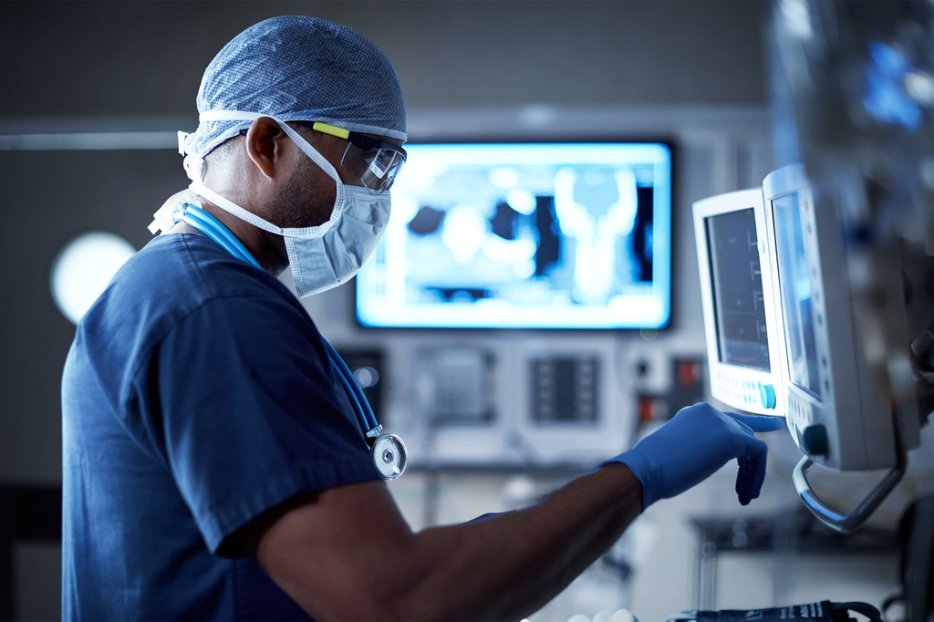

## Data Definition

- group_num
- ID: The patient ID
- outcome: 0 = Alive and 1 = Dead
- age: the age of the patient
- gender: 1 = Male and 2 = Female
- BMI: Body Mass Index
- hypertensive: 0 = with and 1 = without
- atrialfibrillation: 0 = with and 1 = without
- CHD_with_no_MI: Coronary heart disease with Myocardial infarction, 0 = with and 1 without
- diabetes: 0 = with and 1 without
- deficiencyanemias: 0 = with and 1 = without
- depression: 0 = with and 1 = without
- Hyperlipemia:this refers to high concentration of fats or lipids in the blood. 0 = with and 1 = without
- Renal_failure: 0 = without renal failure and 1 = with renal failure
- COPD: chronic obstructive pulmonary disease(A disease causing airflow blockage and breathing related problems). 0 = without and 1 = without
- heart_rate: a range of 60 to 100 bpm is considered normal
- Systolic_blood_pressure: measure of the pressure in arteries when the heart beats.
- Diastolic_blood_pressure: measure of the pressure in the arteries when the heart rests between beats
- Respiratory_rate: this is the number of breathes per minute. The normal range is between 12-20, anything under above or below this range is abnormal. 25 is considered too high.
- temperature
- SP_O2: Oxygen saturation (measure of how much oxygen the blood carries as a percentage of the maximum it could carry). The normal range for healthy individuals is between 96% to 99%
- Urine_output
- hematocrit: percentage volume of red blood cells in the blood.
- RBC: acronym for Red Blood Count.
- MCH: Mean Corpuscular Hemoglobin, this is the average amount of hemoglobin in each of the red blood cells
- MCHC: Mean Cell Hemoglobin Concentration, this is the average concentration of hemoglobin in a given volume of blood.
- MCV: Mean Corpuscular Volume, this is the measure of the average size of the red clood cells
- RDW: red cell distribution width. it is the differences in the volume and size of the red blood cells
- Leucocyte
- Platelets
- Neutrophils
- Basophils
- Lymphocyte
- PT: measure of the time it takes the liquid portion of the blood to clot.
- INR
- NT_proBNP: a measure of heart failure.
- Creatine_kinase
- Creatinine
- Urea_nitrogen
- glucose
- Blood_potassium
- Blood_sodium
- Blood_calcium
- Chloride
- Anion_gap: measures the difference between the negatively and positively charged electrolytes in the blood.
- Magnesium_ion
- PH
- Bicarbonate
- Lactic_acid
- PCO2: Partial Pressure of Carbon Dioxide, this measures the carbondioxide within the arterial or venous blood.
- EF: Ejection Fraction: Used to gauge how healthy the heart is. It is the amount of blood that the heart pumps each time it beats.

# Data Preparation and Preprocessing

> **Note:** The PostgreSQL code solution to the descriptive statistic questions asked are [here](https://raw.githubusercontent.com/xrander/Health-data/master/Health_data_analysis.sql)

## Explanatory Variable and Dependent Variable

The dependent variable for this analysis is the outcome, while other variables are the explanatory variable.

##Understanding the Data

It is important we understand the data

### The Data Structure

```r
# data structure
str(health_rec)
```

```
## spc_tbl_ [1,177 × 51] (S3: spec_tbl_df/tbl_df/tbl/data.frame)
##  $ group_num               : num [1:1177] 1 1 1 1 1 1 1 1 1 1 ...
##  $ ID                      : num [1:1177] 125047 139812 109787 130587 138290 ...
##  $ outcome                 : num [1:1177] 0 0 0 0 0 0 0 0 0 0 ...
##  $ age                     : num [1:1177] 72 75 83 43 75 76 72 83 61 67 ...
##  $ gender                  : num [1:1177] 1 2 2 2 2 1 1 2 2 1 ...
##  $ BMI                     : num [1:1177] 37.6 NA 26.6 83.3 31.8 ...
##  $ hypertensive            : num [1:1177] 0 0 0 0 1 1 1 1 1 1 ...
##  $ atrialfibrillation      : num [1:1177] 0 0 0 0 0 1 0 1 1 0 ...
##  $ CHD_with_no_MI          : num [1:1177] 0 0 0 0 0 0 0 0 0 0 ...
##  $ diabetes                : num [1:1177] 1 0 0 0 0 0 0 1 1 1 ...
##  $ deficiencyanemias       : num [1:1177] 1 1 1 0 1 1 0 1 0 0 ...
##  $ depression              : num [1:1177] 0 0 0 0 0 0 0 0 0 0 ...
##  $ Hyperlipemia            : num [1:1177] 1 0 0 0 0 1 1 0 0 0 ...
##  $ Renal_failure           : num [1:1177] 1 0 1 0 1 1 1 0 1 0 ...
##  $ COPD                    : num [1:1177] 0 1 0 0 1 1 1 0 0 0 ...
##  $ heart_rate              : num [1:1177] 68.8 101.4 72.3 94.5 67.9 ...
##  $ Systolic_blood_pressure : num [1:1177] 156 140 135 126 157 ...
##  $ Diastolic_blood_pressure: num [1:1177] 68.3 65 61.4 73.2 58.1 ...
##  $ Respiratory_rate        : num [1:1177] 16.6 20.9 23.6 21.9 21.4 ...
##  $ temperature             : num [1:1177] 36.7 36.7 36.5 36.3 36.8 ...
##  $ SP_O2                   : num [1:1177] 98.4 96.9 95.3 93.8 99.3 ...
##  $ Urine_output            : num [1:1177] 2155 1425 2425 8760 4455 ...
##  $ hematocrit              : num [1:1177] 26.3 30.8 27.7 36.6 29.9 ...
##  $ RBC                     : num [1:1177] 2.96 3.14 2.62 4.28 3.29 ...
##  $ MCH                     : num [1:1177] 28.2 31.1 34.3 26.1 30.7 ...
##  $ MCHC                    : num [1:1177] 31.5 31.7 31.3 30.4 33.7 ...
##  $ MCV                     : num [1:1177] 89.9 98.2 109.8 85.6 91 ...
##  $ RDW                     : num [1:1177] 16.2 14.3 23.8 17 16.3 ...
##  $ Leucocyte               : num [1:1177] 7.65 12.74 5.48 8.22 8.83 ...
##  $ Platelets               : num [1:1177] 305 246 204 216 251 ...
##  $ Neutrophils             : num [1:1177] 74.7 NA 68.1 81.8 NA ...
##  $ Basophils               : num [1:1177] 0.4 NA 0.55 0.15 NA 0.3 0.2 NA 0.55 NA ...
##  $ Lymphocyte              : num [1:1177] 13.3 NA 24.5 14.5 NA ...
##  $ PT                      : num [1:1177] 10.6 NA 11.3 27.1 NA ...
##  $ INR                     : num [1:1177] 1 NA 0.95 2.67 NA ...
##  $ NT_proBNP               : num [1:1177] 1956 2384 4081 668 30802 ...
##  $ Creatine_kinase         : num [1:1177] 148 60.6 16 85 111.7 ...
##  $ Creatinine              : num [1:1177] 1.958 1.122 1.871 0.586 1.95 ...
##  $ Urea_nitrogen           : num [1:1177] 50 20.3 33.9 15.3 43 ...
```

[output cut: 52 more lines]

```
##   ..   Urea_nitrogen = col_double(),
##   ..   glucose = col_double(),
##   ..   Blood_potassium = col_double(),
##   ..   Blood_sodium = col_double(),
##   ..   Blood_calcium = col_double(),
##   ..   Chloride = col_double(),
##   ..   Anion_gap = col_double(),
##   ..   Magnesium_ion = col_double(),
##   ..   PH = col_double(),
##   ..   Bicarbonate = col_double(),
##   ..   Lactic_acid = col_double(),
##   ..   PCO2 = col_double(),
##   ..   EF = col_double()
##   .. )
##  - attr(*, "problems")=<externalptr>
```

At first glance, all the variables are numeric type. There are 1177 observations and 51 variables. Some of the variables of the data does not follow the data definition. A quick descriptive summary of the data shows this.

```r
# quick descriptive statistics of the data
summary(health_rec)
```

```
##    group_num           ID            outcome            age
##  Min.   :1.000   Min.   :100213   Min.   :0.0000   Min.   :19.00
##  1st Qu.:1.000   1st Qu.:125603   1st Qu.:0.0000   1st Qu.:65.00
##  Median :1.000   Median :151901   Median :0.0000   Median :77.00
##  Mean   :1.299   Mean   :150778   Mean   :0.1352   Mean   :74.06
##  3rd Qu.:2.000   3rd Qu.:176048   3rd Qu.:0.0000   3rd Qu.:85.00
##  Max.   :2.000   Max.   :199952   Max.   :1.0000   Max.   :99.00
##                                   NA's   :1
##      gender           BMI          hypertensive    atrialfibrillation
##  Min.   :1.000   Min.   : 13.35   Min.   :0.0000   Min.   :0.0000
##  1st Qu.:1.000   1st Qu.: 24.33   1st Qu.:0.0000   1st Qu.:0.0000
##  Median :2.000   Median : 28.31   Median :1.0000   Median :0.0000
##  Mean   :1.525   Mean   : 30.19   Mean   :0.7179   Mean   :0.4511
##  3rd Qu.:2.000   3rd Qu.: 33.63   3rd Qu.:1.0000   3rd Qu.:1.0000
##  Max.   :2.000   Max.   :104.97   Max.   :1.0000   Max.   :1.0000
##                  NA's   :215
##  CHD_with_no_MI       diabetes      deficiencyanemias   depression
##  Min.   :0.00000   Min.   :0.0000   Min.   :0.000     Min.   :0.0000
##  1st Qu.:0.00000   1st Qu.:0.0000   1st Qu.:0.000     1st Qu.:0.0000
##  Median :0.00000   Median :0.0000   Median :0.000     Median :0.0000
##  Mean   :0.08581   Mean   :0.4214   Mean   :0.339     Mean   :0.1189
##  3rd Qu.:0.00000   3rd Qu.:1.0000   3rd Qu.:1.000     3rd Qu.:0.0000
##  Max.   :1.00000   Max.   :1.0000   Max.   :1.000     Max.   :1.0000
##
##   Hyperlipemia    Renal_failure         COPD           heart_rate
##  Min.   :0.0000   Min.   :0.0000   Min.   :0.00000   Min.   : 36.00
##  1st Qu.:0.0000   1st Qu.:0.0000   1st Qu.:0.00000   1st Qu.: 72.37
##  Median :0.0000   Median :0.0000   Median :0.00000   Median : 83.61
##  Mean   :0.3798   Mean   :0.3653   Mean   :0.07562   Mean   : 84.58
##  3rd Qu.:1.0000   3rd Qu.:1.0000   3rd Qu.:0.00000   3rd Qu.: 95.91
##  Max.   :1.0000   Max.   :1.0000   Max.   :1.00000   Max.   :135.71
##                                                      NA's   :13
##  Systolic_blood_pressure Diastolic_blood_pressure Respiratory_rate
##  Min.   : 75.0           Min.   : 24.74           Min.   :11.14
##  1st Qu.:105.4           1st Qu.: 52.17           1st Qu.:17.93
##  Median :116.1           Median : 58.46           Median :20.37
##  Mean   :118.0           Mean   : 59.53           Mean   :20.80
##  3rd Qu.:128.6           3rd Qu.: 65.46           3rd Qu.:23.39
##  Max.   :203.0           Max.   :107.00           Max.   :40.90
##  NA's   :16              NA's   :16               NA's   :13
```

[output cut: 49 more lines]

```
##  Min.   : 80.27   Min.   : 6.636   Min.   :1.400   Min.   :7.090
##  1st Qu.: 99.00   1st Qu.:12.250   1st Qu.:1.956   1st Qu.:7.335
##  Median :102.50   Median :13.667   Median :2.092   Median :7.380
##  Mean   :102.28   Mean   :13.925   Mean   :2.120   Mean   :7.379
##  3rd Qu.:105.57   3rd Qu.:15.417   3rd Qu.:2.242   3rd Qu.:7.430
##  Max.   :122.53   Max.   :25.500   Max.   :4.073   Max.   :7.580
##                                                    NA's   :292
##   Bicarbonate     Lactic_acid         PCO2             EF
##  Min.   :12.86   Min.   :0.500   Min.   :18.75   Min.   :15.00
##  1st Qu.:23.45   1st Qu.:1.200   1st Qu.:37.04   1st Qu.:40.00
##  Median :26.50   Median :1.600   Median :43.00   Median :55.00
##  Mean   :26.91   Mean   :1.853   Mean   :45.54   Mean   :48.72
##  3rd Qu.:29.88   3rd Qu.:2.200   3rd Qu.:50.59   3rd Qu.:55.00
##  Max.   :47.67   Max.   :8.333   Max.   :98.60   Max.   :75.00
##                  NA's   :229     NA's   :294
```

We can expect two data type according to the data description. The first is categorical variables for data which min is 0 and max is 1, and the other is numeric variables.

The descriptive statistics also shows the min and max age as 19 and 99.

### Missing values

Next, we investigate the data for missing values. It is alright to have some missing values for some variables, but the outcome should be known, as it is important to see if patients are dead or alive. Outcome will be used to handle the missing data.

```r
# Remove missing data from the outcome variable
health_rec <- health_rec%>%
  filter(!is.na(outcome))
```

#### Categorical Varaibles

```r
categorical <- health_rec %>%
  select(gender, hypertensive:COPD)

unique(is.na(categorical))
```

```
##      gender hypertensive atrialfibrillation CHD_with_no_MI diabetes
## [1,]  FALSE        FALSE              FALSE          FALSE    FALSE
##      deficiencyanemias depression Hyperlipemia Renal_failure  COPD
## [1,]             FALSE      FALSE        FALSE         FALSE FALSE
```

The categorical variables do not have missing values.

#### Numerical Variables distribution

For the numerical variable, the descriptive statistics carried out earlier shows that some numerical variables contains missing values

```r
numerical <- health_rec %>%
  select(-colnames(categorical), -c(1:4))

str(numerical)
```

```
## tibble [1,176 × 37] (S3: tbl_df/tbl/data.frame)
##  $ BMI                     : num [1:1176] 37.6 NA 26.6 83.3 31.8 ...
##  $ heart_rate              : num [1:1176] 68.8 101.4 72.3 94.5 67.9 ...
##  $ Systolic_blood_pressure : num [1:1176] 156 140 135 126 157 ...
##  $ Diastolic_blood_pressure: num [1:1176] 68.3 65 61.4 73.2 58.1 ...
##  $ Respiratory_rate        : num [1:1176] 16.6 20.9 23.6 21.9 21.4 ...
##  $ temperature             : num [1:1176] 36.7 36.7 36.5 36.3 36.8 ...
##  $ SP_O2                   : num [1:1176] 98.4 96.9 95.3 93.8 99.3 ...
##  $ Urine_output            : num [1:1176] 2155 1425 2425 8760 4455 ...
##  $ hematocrit              : num [1:1176] 26.3 30.8 27.7 36.6 29.9 ...
##  $ RBC                     : num [1:1176] 2.96 3.14 2.62 4.28 3.29 ...
##  $ MCH                     : num [1:1176] 28.2 31.1 34.3 26.1 30.7 ...
##  $ MCHC                    : num [1:1176] 31.5 31.7 31.3 30.4 33.7 ...
##  $ MCV                     : num [1:1176] 89.9 98.2 109.8 85.6 91 ...
##  $ RDW                     : num [1:1176] 16.2 14.3 23.8 17 16.3 ...
```

[output cut: 23 more lines]

We are going to impute the missing values in the numerical variables using their mean. We use the e1071 package **impute()** function to impute the means here.

```r
# Load e1071 to impute missing values, and svm model training
library("e1071")
```

```r
imputed_means <- numerical %>%
  impute(what = "mean")
```

##### Distibution of Numerical Variables

The new data will be tidied to visualize the distribution of the numerical variables.

```r
as_tibble(imputed_means) %>%
  pivot_longer(cols = everything(),
               names_to = "variable",
               values_to = "value") %>%
  ggplot(show.legend = F)+
  geom_density(aes(value), col = "tomato2")+
  facet_wrap(~variable, scales = "free")+
  theme_minimal()
```

[figure not shown]

###### Right-skewed Variables

Respiratory rate, RBW, RBC, urea nitrogen, urine output, basophils, BMI, creatine-Kinase, creatinine, glucose, hematocrit, INR, lactic acid, leucocyte, lymphocyte, magnesium ion, NT Pro BMP, PCO2, platelets, PT, and systolic blood pressure are all right skewed.

###### Left-skewed Variables

Only three variables are left skewed. These includes neutrophils, EF, and SP O2.

#### Imputing Missing Values

Next we replace the old values with new ones in the main data frame. In the process, the group_num and ID column were also removed.

```r
health_rec_clean <- health_rec %>%
  select(-c(1,2),-c(names(numerical))) %>% # remove unwanted variables and old numerical variables
  bind_cols(imputed_means) %>% # add imputed values columns to the data frame
  mutate(id = row_number()) %>% # add row numbers to the data frame
  select(id, everything()) # rearrange variables to make id come first

tail(health_rec_clean, 10)
```

| id | outcome | age | gender | hypertensive | atrialfibrillation | CHD_with_no_MI | diabetes | deficiencyanemias | depression | Hyperlipemia | Renal_failure | COPD | BMI | heart_rate | Systolic_blood_pressure | Diastolic_blood_pressure | Respiratory_rate | temperature | SP_O2 | Urine_output | hematocrit | RBC | MCH | MCHC | MCV | RDW | Leucocyte | Platelets | Neutrophils | … |
| --- | --- | --- | --- | --- | --- | --- | --- | --- | --- | --- | --- | --- | --- | --- | --- | --- | --- | --- | --- | --- | --- | --- | --- | --- | --- | --- | --- | --- | --- | --- |
| 1167 | 0 | 83 | 1 | 1 | 1 | 1 | 1 | 0 | 0 | 0 | 1 | 0 | 23.46978 | 63.44444 | 101.46154 | 45.57692 | 21.44444 | 36.67778 | 99.48148 | 1899.277 | 31.00000 | 3.218000 | 27.86000 | 28.92000 | 96.20000 | 18.98000 | 11.860000 | 360.6000 | 91.70000 | … |
| 1168 | 1 | 80 | 1 | 1 | 1 | 0 | 1 | 1 | 0 | 1 | 1 | 0 | 28.94251 | 71.45833 | 108.88000 | 58.08000 | 15.66667 | 37.05556 | 83.06667 | 1899.277 | 26.86000 | 3.180000 | 26.17778 | 30.96667 | 84.66667 | 19.90000 | 8.888889 | 128.3333 | 90.30000 | … |
| 1169 | 0 | 88 | 2 | 1 | 0 | 0 | 1 | 1 | 0 | 1 | 0 | 0 | 26.57148 | 110.16667 | 120.38095 | 62.04762 | 25.08333 | 36.80000 | 93.33333 | 805.000 | 30.56364 | 4.175455 | 23.30000 | 31.83636 | 73.18182 | 22.45455 | 13.227273 | 338.3636 | 80.11559 | … |
| 1170 | 0 | 79 | 1 | 1 | 1 | 0 | 0 | 0 | 0 | 1 | 0 | 0 | 24.22145 | 110.47826 | 117.95455 | 82.68182 | 20.91304 | 36.44444 | 94.50000 | 1825.000 | 28.82000 | 3.063750 | 30.85000 | 32.21250 | 95.75000 | 17.93750 | 7.800000 | 225.1250 | 83.40000 | … |
| 1171 | 0 | 92 | 1 | 1 | 0 | 0 | 0 | 0 | 0 | 0 | 1 | 0 | 23.82217 | 73.61905 | 129.52381 | 51.19048 | 19.80952 | 36.21296 | 97.76190 | 1899.277 | 39.36000 | 4.644000 | 25.92000 | 30.56000 | 85.00000 | 17.36000 | 9.340000 | 262.8000 | 80.13333 | … |
| 1172 | 0 | 62 | 1 | 1 | 1 | 0 | 1 | 0 | 1 | 1 | 1 | 0 | 25.51687 | 100.12500 | 142.54545 | 69.68182 | 24.50000 | 37.05556 | 94.13043 | 1899.277 | 33.62857 | 3.685714 | 27.84286 | 30.54286 | 91.14286 | 15.55714 | 7.742857 | 251.8571 | 81.55000 | … |
| 1173 | 0 | 78 | 1 | 0 | 1 | 0 | 1 | 0 | 1 | 1 | 1 | 0 | 25.82271 | 114.64000 | 101.22222 | 51.88889 | 18.95833 | 35.97222 | 93.52632 | 1899.277 | 28.71579 | 3.270000 | 29.77273 | 33.26364 | 89.54545 | 18.67273 | 22.309091 | 283.0000 | 84.58000 | … |
| 1174 | 0 | 85 | 2 | 1 | 1 | 0 | 1 | 1 | 0 | 0 | 1 | 0 | 23.89178 | 52.72000 | 137.79167 | 40.95833 | 18.68000 | 36.77778 | 98.80000 | 118.000 | 27.68571 | 3.065714 | 26.90000 | 29.80000 | 90.28571 | 17.28571 | 9.228571 | 409.2857 | 65.90000 | … |
| 1175 | 0 | 79 | 2 | 0 | 0 | 1 | 1 | 1 | 1 | 1 | 1 | 0 | 35.28855 | 93.40000 | 94.41667 | 62.45833 | 22.04000 | 36.42222 | 99.56000 | 2585.000 | 33.53750 | 3.446250 | 31.15000 | 32.01250 | 97.37500 | 16.00000 | 6.062500 | 307.3750 | 79.85000 | … |
| 1176 | 0 | 47 | 1 | 1 | 0 | 0 | 1 | 0 | 0 | 0 | 1 | 0 | 23.12138 | 67.28986 | 131.52308 | 72.27692 | 23.46479 | 37.71667 | 99.65217 | 1899.277 | 29.93750 | 2.797143 | 36.77143 | 34.44286 | 106.57143 | 16.15714 | 7.100000 | 275.2857 | 77.00000 | … |

Now we check to find if there are still missing values.

```r
unique(is.na(health_rec_clean))
```

```
##         id outcome   age gender hypertensive atrialfibrillation CHD_with_no_MI
## [1,] FALSE   FALSE FALSE  FALSE        FALSE              FALSE          FALSE
##      diabetes deficiencyanemias depression Hyperlipemia Renal_failure  COPD
## [1,]    FALSE             FALSE      FALSE        FALSE         FALSE FALSE
##        BMI heart_rate Systolic_blood_pressure Diastolic_blood_pressure
## [1,] FALSE      FALSE                   FALSE                    FALSE
##      Respiratory_rate temperature SP_O2 Urine_output hematocrit   RBC   MCH
## [1,]            FALSE       FALSE FALSE        FALSE      FALSE FALSE FALSE
##       MCHC   MCV   RDW Leucocyte Platelets Neutrophils Basophils Lymphocyte
## [1,] FALSE FALSE FALSE     FALSE     FALSE       FALSE     FALSE      FALSE
##         PT   INR NT_proBNP Creatine_kinase Creatinine Urea_nitrogen glucose
## [1,] FALSE FALSE     FALSE           FALSE      FALSE         FALSE   FALSE
##      Blood_potassium Blood_sodium Blood_calcium Chloride Anion_gap
## [1,]           FALSE        FALSE         FALSE    FALSE     FALSE
##      Magnesium_ion    PH Bicarbonate Lactic_acid  PCO2    EF
## [1,]         FALSE FALSE       FALSE       FALSE FALSE FALSE
```

All numerical variable missing values are replaced by their means.

# Exploratory Data Analysis

A majority of the question asked are descriptive statistics questions and answers will be provided using visualization and tables.

## Descriptive Statistics

### What is the percentage age distribution according to age groups

**The age group with the highest frequency**: To do this, we have to bin the age variable, creating a class range, then we can create a summary of the age_group and see their frequency

```r
# Create bins
age_categories <- seq(0, 120, by = 20) # We assume the highest age is not above 120 years old

# Create age interval variable
health_rec_clean <- health_rec_clean %>%
  mutate(age_group = cut(age,
                         breaks = age_categories,
                         include.lowest = T, # To indicate if x is the lowest
                         ordered_result = F),#This ensures that the factor variable is not ordered
         age_group =  ifelse(age_group == "[0,20]", "0-20",
                             ifelse(age_group == "(20,40]", "20-40",
                                    ifelse(age_group == "(40,60]", "40-60",
                                           ifelse(age_group == "(60,80]", "60-80", "80-100")))), # Change the group names to ensure consistency
         age_group = factor(age_group, levels = c("0-20", "20-40","40-60", "60-80", "80-100")))
```

```r
health_rec_clean %>%
  group_by(age_group) %>%
  summarize(frequency = n()) %>%
  ggplot(aes("", frequency, fill = age_group))+
  geom_col(color = "white")+
  geom_text(aes(label = paste0(round(frequency/sum(frequency)*100, 1), "%")),
              position = position_stack(vjust = 0.5))+
  scale_fill_manual(values = c("pink", "coral", "tomato1", "orangered1", "indianred1"))+
  labs(x = NULL,
       y = NULL,
       fill = "Age Group",
       title = "Pie Chart of Age Groups")+
  coord_polar(theta = "y", start = 0)+
  theme(legend.position = "top",
        axis.line = element_blank(),
        plot.background = element_blank(),
        rect = element_blank(),
        axis.text = element_blank(),
        axis.ticks = element_blank(),
        axis.title = element_blank())
```

[figure not shown]

Older people are the highest in the hospital, with people between 60 - 80 years old having being the highest in the clinic and people more than 80 years old being the next most occurring patients. To know the age(not age group) that is most occurring, we can simply group by the age them.

### Top Occuring ages in the Hospital

```r
health_rec_clean %>%
  group_by(age) %>%
  summarize(frequency = n()) %>%
  arrange(desc(frequency)) %>%
  top_n(n = 6)
```

| age | frequency |
| --- | --- |
| 89 | 141 |
| 84 | 48 |
| 81 | 43 |
| 80 | 40 |
| 78 | 39 |
| 83 | 39 |

The highest count of patients in the clinic are aged 89, 84 and 81 years respectively.

### What is the number of dead patients for each gender*

```r
health_rec_clean %>%
  filter(outcome == 1) %>%
  group_by(gender, age_group) %>%
  summarize(dead_patients = length(outcome)) %>%
  arrange(desc(dead_patients)) %>%
  ggplot(aes(age_group, dead_patients, fill = factor(gender))) +
  geom_col(position = "dodge")+
  scale_fill_manual(values = c("tomato2", "thistle4"),
                    labels = c("Male", "Female"))+
  labs(x = "Age group",
       y = "Dead patients",
       fill = "Gender",
       title = "Dead counts across the different gender")+
  expand_limits(y = c(0, 40))+
  theme_bw()
```

[figure not shown]

The chart shows the dead patients according to age group and gender. The age group 80-100 years for females have the highest count of death.

### Gender Frequency

The gender with the highest count in the clinic is the female gender as show below

```r
health_rec_clean %>%
  select(gender) %>%
  mutate(gender = ifelse(gender == 1, "Male", "Female")) %>%
  group_by(gender) %>%
  count() %>%
  ggplot(aes(gender, n))+
  geom_col(fill = c("tan3", "wheat4"))+
  ggtitle("Frequency of Patients According to Their Gender")+
  theme_bw()
```

[figure not shown]

#what is the death rate of both gender for a given age group?

```r
health_rec_clean %>%
  mutate(outcome = ifelse(outcome == 0, "Alive", "Dead"),
         gender = ifelse(gender == 1, "Male", "Female")) %>%
  group_by(gender, outcome, age_group) %>%
  count() %>%
  pivot_wider(names_from = outcome,
              values_from = n,
              values_fill = 0) %>%
  mutate(total = sum(Alive, Dead),
         death_per_100 = Dead/100,
         death_ratio = round(Dead/total, 2))
```

| gender | age_group | Alive | Dead | total | death_per_100 | death_ratio |
| --- | --- | --- | --- | --- | --- | --- |
| Female | 0-20 | 1 | 0 | 1 | 0.00 | 0.00 |
| Female | 20-40 | 5 | 0 | 5 | 0.00 | 0.00 |
| Female | 40-60 | 76 | 9 | 85 | 0.09 | 0.11 |
| Female | 60-80 | 231 | 33 | 264 | 0.33 | 0.12 |
| Female | 80-100 | 226 | 37 | 263 | 0.37 | 0.14 |
| Male | 0-20 | 1 | 0 | 1 | 0.00 | 0.00 |
| Male | 20-40 | 11 | 2 | 13 | 0.02 | 0.15 |
| Male | 40-60 | 76 | 10 | 86 | 0.10 | 0.12 |
| Male | 60-80 | 219 | 34 | 253 | 0.34 | 0.13 |
| Male | 80-100 | 171 | 34 | 205 | 0.34 | 0.17 |

### Disease and Death

Now we will investigate the 159 death occurrences that is present in the clinic and relate it to some of the diseases.

```r
dead_patients <- health_rec_clean %>%
  filter(outcome == 1) %>%
  select(outcome:COPD)
```

**Tidying the data for visualization**

```r
dead_patients_tidy <- dead_patients %>%
  pivot_longer(cols = c(hypertensive:COPD),
               names_to = "diseases",
               values_to = "state") %>%
  mutate(outcome = ifelse(outcome == 0, "Alive", "Dead"),
         gender = ifelse(gender == 1, "Male", "Female"),
         state = ifelse(diseases == "Renal_failure", "Not having", "Having"),
         state = ifelse(diseases != "Renal_failure", "Having", "Not Having"))
```

```r
dead_patients_tidy %>%
  ggplot(aes(state, fill = gender))+
  geom_bar(position = "dodge")+
  scale_fill_manual(values = c("wheat4", "tan3"))+
  facet_wrap(~diseases, scales = "free_y")+
  theme_bw()
```

[figure not shown]

## Correlation Analysis

```r
# Load corrplot package for correlation matrix
library('corrplot')
# Correlation for numerical variables
correlation_plot <- cor(health_rec_clean[,c(1:2, 13:49)])

# Visualize correlation
ggplot(melt(correlation_plot), aes(Var1, Var2, fill = value, label = round(value,2)))+
  geom_tile()+
  geom_text(aes(label= ifelse(value>0.1, as.character(round(value, 1)), "")))+
  scale_fill_gradient(low = "tomato",
                      high = "skyblue")+
  labs(title = "Correlation plot of variables")+
  theme_minimal()+
  theme(axis.text.x = element_text(angle = 45, hjust = 1))
```

[figure not shown]

# Outcome Prediction

Machine Learning Algorithms to be used We are going to predict the outcome of any one patients making use of four machine learning algorithms viz:

- Logistic Regression
- Random Forest Classifier
- Support Vector Machines (SVMs)
- Gradient Boosting Algorithms (XGboosts)

## Data Splitting

Split the data and set seed.

```r
# Load caret package for data spliting
library("caret")
# Set seed to ensure reproducibility
set.seed(1599)

# Split the data to train and test data
training_data_index <- createDataPartition(health_rec_clean$outcome,
                    p = 0.8,
                    list = F)

# Training data
health_rec_train <- health_rec_clean[training_data_index, ]
# Test data
health_rec_test <- health_rec_clean[-training_data_index,]
```

```r
# Remove id number and age_group columns
health_rec_train <- health_rec_train %>%
  select(-c(1, 51))

health_rec_test <- health_rec_test %>%
  select(-c(1, 51))
```

**Preview split data**

```r
head(health_rec_test, n = 5)
```

| outcome | age | gender | hypertensive | atrialfibrillation | CHD_with_no_MI | diabetes | deficiencyanemias | depression | Hyperlipemia | Renal_failure | COPD | BMI | heart_rate | Systolic_blood_pressure | Diastolic_blood_pressure | Respiratory_rate | temperature | SP_O2 | Urine_output | hematocrit | RBC | MCH | MCHC | MCV | RDW | Leucocyte | Platelets | Neutrophils | Basophils | … |
| --- | --- | --- | --- | --- | --- | --- | --- | --- | --- | --- | --- | --- | --- | --- | --- | --- | --- | --- | --- | --- | --- | --- | --- | --- | --- | --- | --- | --- | --- | --- |
| 0 | 61 | 2 | 1 | 1 | 0 | 1 | 0 | 0 | 0 | 1 | 0 | 19.99224 | 91.91667 | 98.43478 | 52.65217 | 18.58333 | 37.10317 | 98.04167 | 1625 | 31.24118 | 3.417500 | 29.19375 | 31.91875 | 91.56250 | 15.50625 | 3.806250 | 129.8824 | 67.00000 | 0.5500000 | … |
| 0 | 70 | 2 | 1 | 0 | 0 | 1 | 0 | 0 | 1 | 0 | 0 | 50.46121 | 95.62963 | 149.03571 | 48.78571 | 17.48148 | 37.55556 | 95.25000 | 1305 | 27.48182 | 3.182222 | 28.26667 | 33.03333 | 85.77778 | 15.48889 | 10.222222 | 185.3333 | 80.11559 | 0.4056846 | … |
| 0 | 87 | 2 | 1 | 0 | 0 | 1 | 0 | 0 | 1 | 1 | 0 | 35.19894 | 73.48000 | 159.69565 | 59.08696 | 20.69231 | 36.93333 | 97.44000 | 3700 | 28.56000 | 2.912000 | 32.50000 | 33.14000 | 98.00000 | 15.06000 | 7.380000 | 230.2000 | 83.50000 | 0.2000000 | … |
| 0 | 89 | 2 | 0 | 0 | 0 | 0 | 1 | 0 | 0 | 1 | 0 | 30.18828 | 70.08333 | 112.41667 | 50.91667 | 25.58333 | 36.00794 | 95.54167 | 2415 | 27.66000 | 2.917778 | 30.44444 | 32.07778 | 94.88889 | 15.52222 | 6.511111 | 445.5556 | 78.05000 | 0.3500000 | … |
| 1 | 89 | 1 | 1 | 1 | 0 | 0 | 0 | 0 | 0 | 0 | 0 | 30.18828 | 90.44444 | 106.94118 | 40.76471 | 24.05882 | 36.28889 | 96.11765 | 1370 | 29.39286 | 3.296000 | 29.56000 | 33.37000 | 88.60000 | 18.39000 | 5.900000 | 330.7000 | 81.86667 | 0.5000000 | … |

```r
head(health_rec_train, n = 5)
```

| outcome | age | gender | hypertensive | atrialfibrillation | CHD_with_no_MI | diabetes | deficiencyanemias | depression | Hyperlipemia | Renal_failure | COPD | BMI | heart_rate | Systolic_blood_pressure | Diastolic_blood_pressure | Respiratory_rate | temperature | SP_O2 | Urine_output | hematocrit | RBC | MCH | MCHC | MCV | RDW | Leucocyte | Platelets | Neutrophils | Basophils | … |
| --- | --- | --- | --- | --- | --- | --- | --- | --- | --- | --- | --- | --- | --- | --- | --- | --- | --- | --- | --- | --- | --- | --- | --- | --- | --- | --- | --- | --- | --- | --- |
| 0 | 72 | 1 | 0 | 0 | 0 | 1 | 1 | 0 | 1 | 1 | 0 | 37.58818 | 68.83784 | 155.8667 | 68.33333 | 16.62162 | 36.71429 | 98.39474 | 2155 | 26.27273 | 2.960000 | 28.25000 | 31.52000 | 89.900 | 16.22000 | 7.650000 | 305.100 | 74.65000 | 0.4000000 | … |
| 0 | 75 | 2 | 0 | 0 | 0 | 0 | 1 | 0 | 0 | 0 | 1 | 30.18828 | 101.37037 | 140.0000 | 65.00000 | 20.85185 | 36.68254 | 96.92308 | 1425 | 30.78000 | 3.138000 | 31.06000 | 31.66000 | 98.200 | 14.26000 | 12.740000 | 246.400 | 80.11559 | 0.4056846 | … |
| 0 | 83 | 2 | 0 | 0 | 0 | 0 | 1 | 0 | 0 | 1 | 0 | 26.57263 | 72.31818 | 135.3333 | 61.37500 | 23.64000 | 36.45370 | 95.29167 | 2425 | 27.70000 | 2.620000 | 34.32000 | 31.30000 | 109.800 | 23.82000 | 5.480000 | 204.200 | 68.10000 | 0.5500000 | … |
| 0 | 43 | 2 | 0 | 0 | 0 | 0 | 0 | 0 | 0 | 0 | 0 | 83.26463 | 94.50000 | 126.4000 | 73.20000 | 21.85714 | 36.28704 | 93.84615 | 8760 | 36.63750 | 4.277500 | 26.06250 | 30.41250 | 85.625 | 17.03750 | 8.225000 | 216.375 | 81.80000 | 0.1500000 | … |
| 0 | 75 | 2 | 1 | 0 | 0 | 0 | 1 | 0 | 0 | 1 | 1 | 31.82484 | 67.92000 | 156.5600 | 58.12000 | 21.36000 | 36.76190 | 99.28000 | 4455 | 29.93333 | 3.286667 | 30.66667 | 33.66667 | 91.000 | 16.26667 | 8.833333 | 251.000 | 80.11559 | 0.4056846 | … |

## Model Building and Tuning

### Logistic Regression

####Training the model

```r
logistic_model <- glm(formula = outcome ~ .,
                      family = "binomial",
                      data = health_rec_train)
```

#### Making Predictions

```r
logistic_pred <- ifelse(predict(logistic_model, health_rec_test) >= 0.5, 1, 0)
```

```r
mean(health_rec_test$outcome == logistic_pred)
```

```
## [1] 0.8808511
```

The logistic model is having a 88.1% accuracy.

### Random Forest Classifier

Random forest classifier uses multiple decision tree models and try to mitigate the overfitting from a single decision tree by aggregating the decision from multiple decision trees.

```r
# load randomForest library
library("randomForest")
```

#### Hypertuning parameter for Random Forest

```r
# Create parameter grid for search values

param_grid <- expand.grid(mtry = c(50, 200, 300,500, 700))

# define control function for tuning
control <- trainControl(method = "cv", number = 5) # Use 5 folds cross-validation

model <- train(factor(outcome) ~ ., data = health_rec_train, method = "rf", trControl = control, tuneGrid = param_grid)
print(model)
```

```
## Random Forest
##
## 941 samples
##  48 predictor
##   2 classes: '0', '1'
##
## No pre-processing
## Resampling: Cross-Validated (5 fold)
## Summary of sample sizes: 752, 754, 752, 753, 753
## Resampling results across tuning parameters:
##
##   mtry  Accuracy   Kappa
##    50   0.8767351  0.2895012
##   200   0.8746017  0.2697694
##   300   0.8809792  0.3021321
##   500   0.8767351  0.2762276
##   700   0.8767181  0.2821706
##
## Accuracy was used to select the optimal model using the largest value.
## The final value used for the model was mtry = 300.
```

#### Training the Random Forest Model

```r
rf_model <- randomForest(outcome ~ .,
                         data = health_rec_train,
                         ntree = 300) # train rf model with best parameter from hypertuning
```

#### Predicting the outcome

```r
rf_pred <- ifelse(predict(rf_model, health_rec_test, type = "response") >= 0.5, 1, 0)
```

```r
mean(health_rec_test$outcome == rf_pred)
```

```
## [1] 0.8765957
```

The model is having 87.6% accuracy a bit lower than the logistic regression model.

### Support Vector Machines (SVM)

```r
# mutate outcome to factor type
health_rec_train2 <- health_rec_train %>%
  mutate(outcome = factor(outcome))

health_rec_test2 <- health_rec_test %>%
  mutate(outcome = factor(outcome))
svm_model <- svm(outcome ~ .,
                 data = health_rec_train2,
                 kernel = "linear")

summary(svm_model)
```

```
##
## Call:
## svm(formula = outcome ~ ., data = health_rec_train2, kernel = "linear")
##
##
## Parameters:
##    SVM-Type:  C-classification
##  SVM-Kernel:  linear
##        cost:  1
##
## Number of Support Vectors:  261
##
##  ( 140 121 )
##
##
## Number of Classes:  2
##
## Levels:
##  0 1
```

#### Predicting with the outcome with SVM

```r
svm_pred <- predict(svm_model, health_rec_test2)
```

```r
mean(health_rec_test2$outcome == svm_pred)
```

```
## [1] 0.8808511
```

The model is having 88.1% accuracy, similar to logistic regression

### XGBoost

Next we will use the xgboost package

```r
#load the xgboost library
library(xgboost)
```

#### XGBoost data Preparation

We create the xgboost data type

```r
# Create XGBosst data structure for test and train data
dtrain <- xgb.DMatrix(data = as.matrix(health_rec_train[, -1]), label = as.matrix(health_rec_train[, 1]))
dtest <- xgb.DMatrix(data = as.matrix(health_rec_test[, -1]))
```

#### Training the Data

Next we train the data

```r
# Set parameter structure
params <- list(
  objective = "binary:logistic",
  max_depth = 10,
  eval_metric = "logloss"
)
# Train the XGBoost model
xgb_model <- xgboost(params = params,
                     data = dtrain,
                     nthread = 2,
                     nrounds = 200)
```

#### Predicting with the Model

Now we can make predictions

```r
xgboost_pred <- ifelse(predict(xgb_model, dtest, type = "class") >=0.5, 1, 0)
```

```r
mean(xgboost_pred == health_rec_test$outcome)
```

```
## [1] 0.9021277
```

The model is having a 90% accuracy which is the best performance so far.

## Model Evaluation

```r
table(log_predicted = logistic_pred, actual = health_rec_test$outcome)
```

```
##              actual
## log_predicted   0   1
##             0 204  27
##             1   1   3
```

### Random Forests Classifier

```r
table(random_forest_predicted = rf_pred, actual = health_rec_test$outcome)
```

```
##                        actual
## random_forest_predicted   0   1
##                       0 203  27
##                       1   2   3
```

### SVM

```r
table(prediction = svm_pred, actual = health_rec_test2$outcome)
```

```
##           actual
## prediction   0   1
##          0 204  27
##          1   1   3
```

### XGBoosts

```r
table(xgboost_pred, health_rec_test$outcome)
```

```
##
## xgboost_pred   0   1
##            0 203  21
##            1   2   9
```

Predictions by XGBoost is the best so far, it performs better in predicting actual death than other models

# Conclusion

Four models, XGBoost, logistic regression, SVM and random forest, were tested to see which is having the best outcome. XGBoost is having the best prediction with 90% probability of success.

[Back to Homepage](https://olamideadu.com)